# **Clases BioEstadística Uno en video**

John J Estrada

2021-06-09

# Fechas de Evaluación primer semestre 2021

[output not shown]

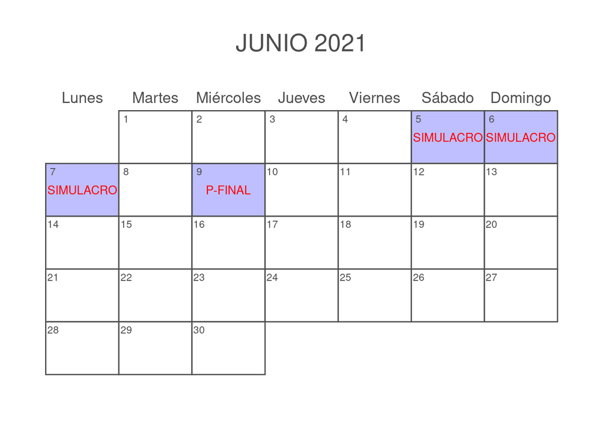

# Clases semestre 01-2021

[Clase Viernes 29 de enero 2021](https://ucesedu-my.sharepoint.com/:v:/g/personal/jestrada_ces_edu_co/EdQUBmP-znBMjlmyfQKOilQBh5eosZ4SAGVLej5rUJfPcA?e=VGrR71)

[Clase Miércoles 3 de febrero 2021](https://ucesedu-my.sharepoint.com/:v:/g/personal/jestrada_ces_edu_co/EffBi6uflMRLlMbJDVLzeekBuFbR0SQDmnzi4aum-p9q1w?e=PVvFQW)

[Clase Viernes 05 de febrero 2021](https://ucesedu-my.sharepoint.com/:v:/g/personal/jestrada_ces_edu_co/Ec0yaKxTqHBOviSVCUVcmhMB6sB4BDyi9_5I1L1VhpfgUg?e=eldCgf)

[Clase Miércoles 10 de febrero 2021](https://ucesedu-my.sharepoint.com/:v:/g/personal/jestrada_ces_edu_co/EU4jmyOggMRKiVB2NRjk5a4B1bgRPiiM7sfyxGewXA6ocw?e=NHTTgV)

[Clase Viernes 12 de febrero 2021](https://ucesedu-my.sharepoint.com/:v:/g/personal/jestrada_ces_edu_co/EfvCzSZKWJlFlMGcm6Bqo3MBoWeuBlH5r3f8IUU3KhrViA?e=uSVdmE)

[Clase Miércoles 17 de febrero 2021](https://ucesedu-my.sharepoint.com/:v:/g/personal/jestrada_ces_edu_co/ET-frq1eAmNMvpW2wgMNO3MBOgJ6w7nU5kOGbEcBmcjrag?e=sF7cPE)

Clase Viernes 19 de febrero 2021- No está disponible por problemas técnicos

[Clase Miércoles 24 de febrero 2021](https://ucesedu-my.sharepoint.com/:v:/g/personal/jestrada_ces_edu_co/EWhC9iNgNnVAq1DxxeFlvS0B-0IN_hKX0P74mg2mIEAcjg?e=7NvOpC)

[Clase Miércoles 17 de Marzo 2021](https://ucesedu-my.sharepoint.com/:v:/g/personal/jestrada_ces_edu_co/EbYofyr3-qpBoRLVOCpmFq0Bs_aTeSqz1rlOu52BD0IPRQ?e=xQIzD9)

[Clase Miércoles 19 de Marzo 2021](https://ucesedu-my.sharepoint.com/:v:/g/personal/jestrada_ces_edu_co/Efd08o_rdXpEiHZ3v8Nz15MBUTN-2SROjWMlOJ4M9t1gYA?e=JFvPVM)

[Clase Viernes 09 de Abril 2021](https://ucesedu-my.sharepoint.com/:v:/g/personal/jestrada_ces_edu_co/EfYTCQNW3IxFkk2zxaOtQA8BJNr9556mQpLGg-e9-gx-fA?e=cu3xb3)

[Clase Miércoles 14 de Abril 2021](https://ucesedu-my.sharepoint.com/:v:/g/personal/jestrada_ces_edu_co/ET11hZg-S5ZGvuuEeURZ_TYBqcZBcTcjq8EYZG9DXb1A9Q?e=gDXVqq)

[Clase Viernes 16 de Abril 2021](https://ucesedu-my.sharepoint.com/:v:/g/personal/jestrada_ces_edu_co/EQBl0YL5SnREgcWWaviV7sMBNxq87OIK0jnX4vnblRnhIA?e=LHCYy7)

[Clase Miércoles 21 de Abril 2021](https://ucesedu-my.sharepoint.com/:v:/g/personal/jestrada_ces_edu_co/ER8kIV5Rg0hMvLLBHE65iiUBLwkMViutBHVw2XH3eiGn9g?e=GQX8wB)

[Clase Viernes 23 de Abril 2021](https://ucesedu-my.sharepoint.com/:v:/g/personal/jestrada_ces_edu_co/ESHzyvNScFpPvbPwQV2jAL8B_EbDWprlTF0o8yh7v9v0aw?e=ZrUClF)

[Clase Miércoles 19 de Mayo 2021](https://ucesedu-my.sharepoint.com/:v:/g/personal/jestrada_ces_edu_co/EcROn-XndQFLgcaBvq8YOGIBNtpLCjpBc6vYA96AB4ZhRw?e=u10b4I)

[Clase Viernes 21 de Mayo 2021](https://ucesedu-my.sharepoint.com/:v:/g/personal/jestrada_ces_edu_co/EZPtq9UgcOhJs5OMfXY3lWwBK4h8hn1bF2KyPFaCF1gMxA?e=Jyu8iL)

[Clase Miércoles 26 de Mayo 2021](https://ucesedu-my.sharepoint.com/:v:/g/personal/jestrada_ces_edu_co/EWXiQ6IeM1tBhL4d4Zt6aIMBfEgqkCZhIGCd77JtA9bBkg?e=nVgE7Y)

[Clase Viernes 28 de Mayo 2021](https://ucesedu-my.sharepoint.com/:v:/g/personal/jestrada_ces_edu_co/EYmFu3VlfDlDhcRyk8yPt6QBzcx1hRegE3f5FQDKMWEj_A?e=lgMMOw)

[Clase Miércoles 02 de Junio 2021](https://ucesedu-my.sharepoint.com/:v:/g/personal/jestrada_ces_edu_co/EbBbeHswhBFAmUEpGKF7CY8BAyi8vKhgxeUhx7aPOpVhmQ?e=gfSuDS)

[Tema de la Normal- ClaseFinal](https://ucesedu-my.sharepoint.com/:v:/g/personal/jestrada_ces_edu_co/ESXZBrhBIA5OsCsDLFpC4sMBCbZ5dYO3pcJgJVpFt19Uvw?e=pMZK8O)

# Bibliografía

- Samuels, M., Witmer, J., & Schaffner, A. (2012). Statistics for the life sciences (4 ed.). Boston: Pearson Education.
- Milton, J. S. (2001). Estadística para la biología y ciencias de la salud (3 ed.). Madrid: McGraw- Hill/Interamericana.
- Daniel, W. W. 2004. Bioestadística. Base para el análisis de las ciencias de la salud. 4era. Ed. Limusa Wiley Noriega Editores. México.
- Johnson, R. A. & Bhattacharyya, G. K. (2010). Statistics. Principles and Methods (6 ed.). New York: John Wiley and Sons, Inc
- Zar, J. (1999). Biostatistical analysis (5 ed.). Prentice hall Upper Saddle River, NJ.
- Zuur, A., Ieno, E., & Meesters, E. (2009). A Beginner’s Guide to R. Springer.